# Heart Disease Indicators

26/04/2022

## Table of Contents

## Objective

- To indicate what factors may contribute to heart disease.

## The Data Analyzed

- In all analysis, the common contributors of Heart Disease are included, such as Cholesterol, Age and Blood Pressure.
  - The data indicates that there does appear to be a connection between higher Cholesterol, Age and Blood Pressure with a greater risk of Heart Disease.
- Other metrics analyzed:
  - Pre-diabetics and diabetics
  - ST-T wave abnormality
  - ECG wave types
  - Exercise angina
  - Chest pain type
  - A lower max heart rate

## Common Indicators

- Heart Disease and Cholesterol

```
##   Heart Disease Cholesterol
## 1             0    238.7692
## 2             1    251.0618
```

- Heart Disease and Blood Pressure

```
##   Heart Disease Blood Pressure
## 1             0       130.1641
## 2             1       136.1545
```

- Heart Disease and Age

```
##   Heart Disease  Average Age
## 1             0     50.17179
## 2             1     55.85112
```

## Other Indicators

- Heart Disease and Diabetes

```
##   Heart Disease  Diabetes
## 1             0 0.1102564
## 2             1 0.2303371
```

- Heart Disease and ST-T Wave Abnormalities

```
##   Heart Disease ST-T Wave Abnormality
## 1             0             0.3938462
## 2             1             1.4578652
```

- Heart Disease and ECG Wave Types

```
##   ECG Wave Type Heart Disease Risk
## 1          Down          0.7441860
## 2          Flat          0.7881356
## 3            Up          0.1289398
```

- Heart Disease and Exercise Angina

```
##   Heart Disease Exercise Angina
## 1             0       0.1282051
## 2             1       0.6657303
```

- Heart Disease and Chest Pain Types

```
##   Chest Pain Type Heart Disease Risk
## 1             ASY          0.7405405
## 2             ATA          0.1265060
## 3             NAP          0.2721893
## 4              TA          0.3658537
```

- Heart Disease and Max Heart Rate

```
##   Heart Disease Max Heart Rate
## 1             0       149.0590
## 2             1       130.5506
```

## Visualizations

## Diabetes and Heart Disease

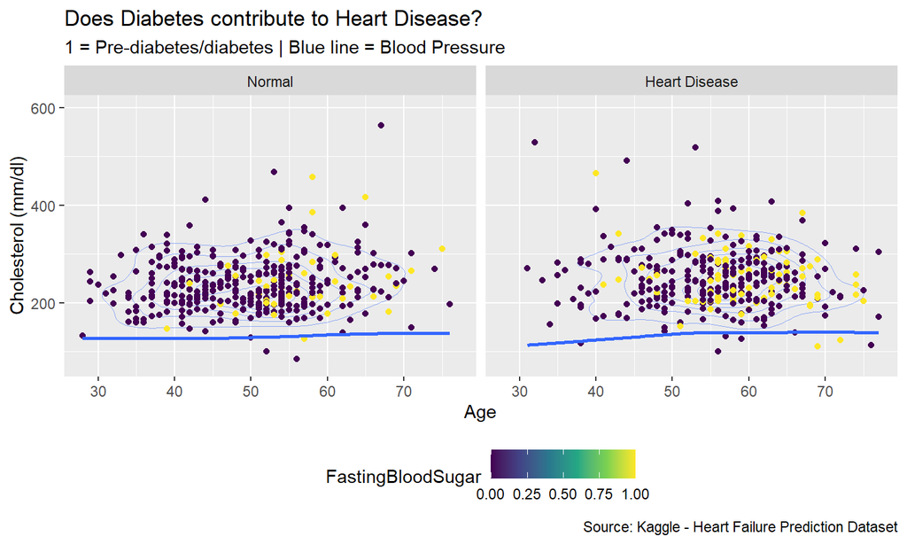

## ST-T Wave Abnormality and Heart Disease

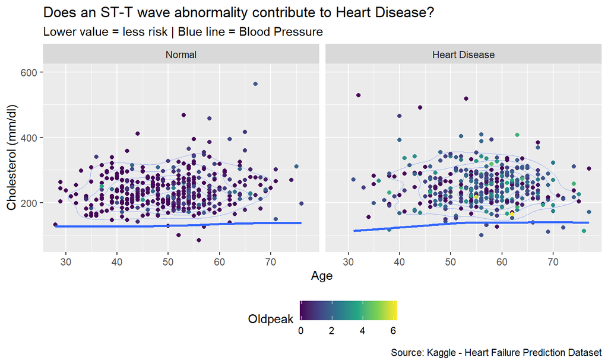

## ECG Wave Types and Heart Disease

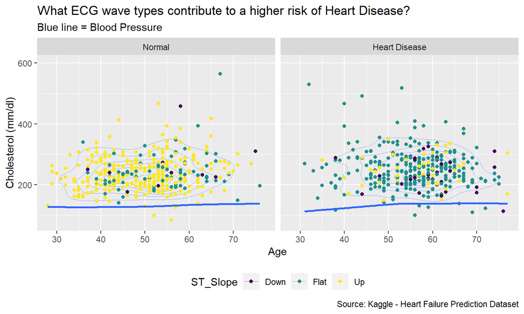

## Exercise Angina and Heart Disease

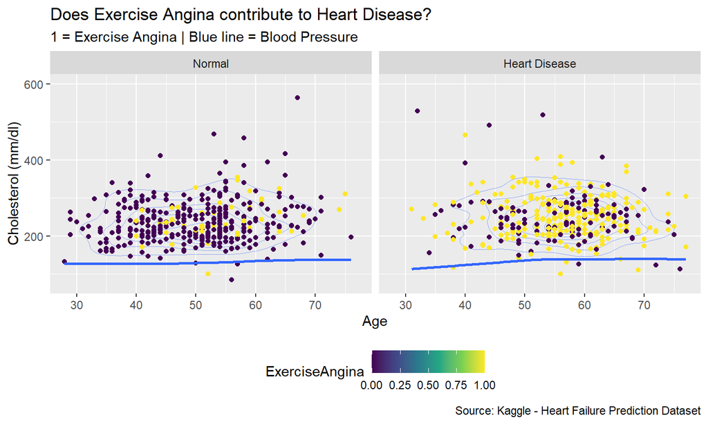

## Chest Pain Type vs Heart Disease

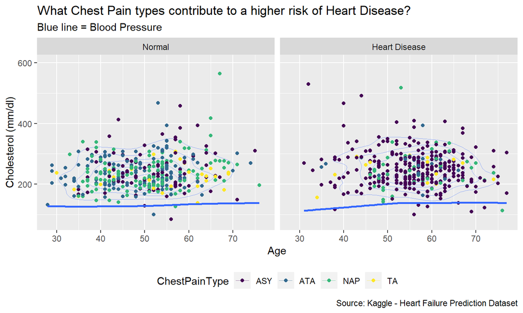

## Max Heart Rate and Heart Disease

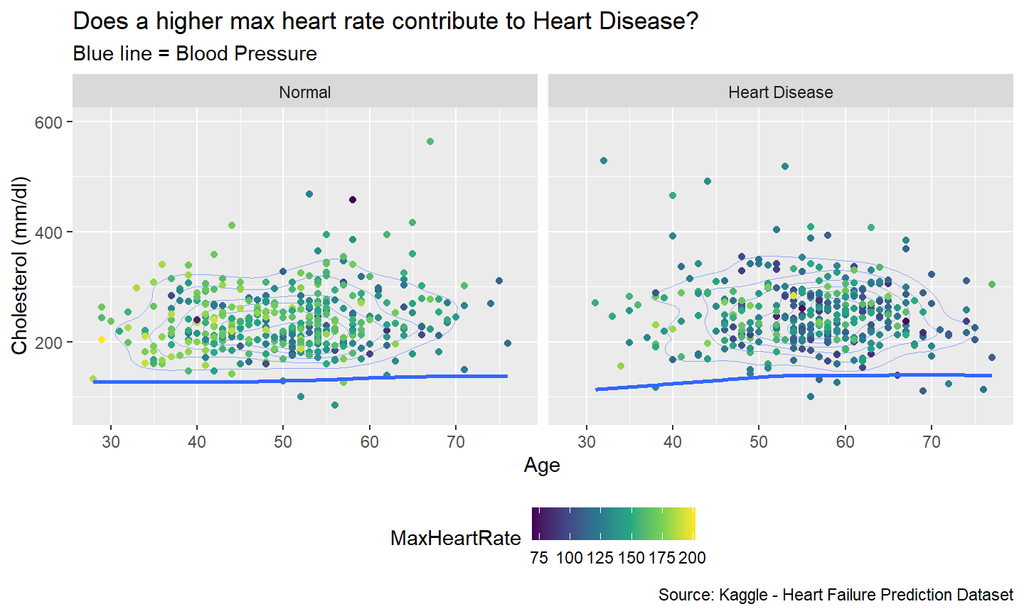

## Conclusion

- In addition to Cholesterol, Age and Blood Pressure, the following appear to lead to a greater risk of Heart Diease:
  - Pre-diabetes / diabetes
  - A higher ST-T wave abnormality value
  - Flat and down ECG wave types
  - Exercise angina
  - Asymptomatic chest pain
  - A lower max heart rate

## Recommendations

- Certain lifestyle changes, such as diet and exercise could possibly help mitigate some, if not all, risk factors of Heart Disease to a certain extent. However, this is not professional medical advice and one should consult their healthcare practitoner.